# IODS course project

Heikki Niemi

# Introduction to Open Data Science - Course Project

# About the project

```r
# This is a so-called "R chunk" where you can write R code.

date()
```

```
## [1] "Fri Dec  9 13:51:12 2022"
```

## Comments about the course

I have some experience using R and Rstudio from previous statistics courses I have attended. I would like to learn more about statistics and especially modelling and different types of regression analysis so that I can better use them in my own research. I found the course by going through the doctoral program’s course catalog.

Because I have used R and also tidyverse before, I only skimmed through the first chapters of the R for Health Data Science book to refresh my memory. The book seems quite good. I like ggplot a lot - it’s very powerful in creating different graphics. However, it is sometimes a bit complicated when you want to make some specific changes to a plot.

## My github repository

https://github.com/hjniemi/IODS-project.

# Assignment 2 - Data analysis exercise

```r
date()
```

```
## [1] "Fri Dec  9 13:51:12 2022"
```

### Data analysis

First we load the required packages and read the data.

We use the dataset learning2014 (http://www.helsinki.fi/~kvehkala/JYTmooc/JYTOPKYS3-data.txt), which contains data about a survey of university students and their attitudes towards learning.

```r
library(tidyverse)
library(GGally)
lrn14 <- read_csv("data/learning2014.csv")
```

```r
#Dimensions of the data
dim(lrn14)
```

```
## [1] 166   7
```

```r
#Structure of the data
str(lrn14)
```

```
## spc_tbl_ [166 × 7] (S3: spec_tbl_df/tbl_df/tbl/data.frame)
##  $ gender  : chr [1:166] "F" "M" "F" "M" ...
##  $ age     : num [1:166] 53 55 49 53 49 38 50 37 37 42 ...
##  $ attitude: num [1:166] 3.7 3.1 2.5 3.5 3.7 3.8 3.5 2.9 3.8 2.1 ...
##  $ deep    : num [1:166] 3.58 2.92 3.5 3.5 3.67 ...
##  $ stra    : num [1:166] 3.38 2.75 3.62 3.12 3.62 ...
##  $ surf    : num [1:166] 2.58 3.17 2.25 2.25 2.83 ...
##  $ points  : num [1:166] 25 12 24 10 22 21 21 31 24 26 ...
##  - attr(*, "spec")=
##   .. cols(
##   ..   gender = col_character(),
##   ..   age = col_double(),
##   ..   attitude = col_double(),
##   ..   deep = col_double(),
##   ..   stra = col_double(),
##   ..   surf = col_double(),
##   ..   points = col_double()
##   .. )
##  - attr(*, "problems")=<externalptr>
```

The dataset contains 166 observations (students) and 7 variables: age, gender, exam points (points) and summary variables of questions related to deep learning (deep), surface learning (surf), strategic learning (stra) and students’ attitude towards statistics (attitude).

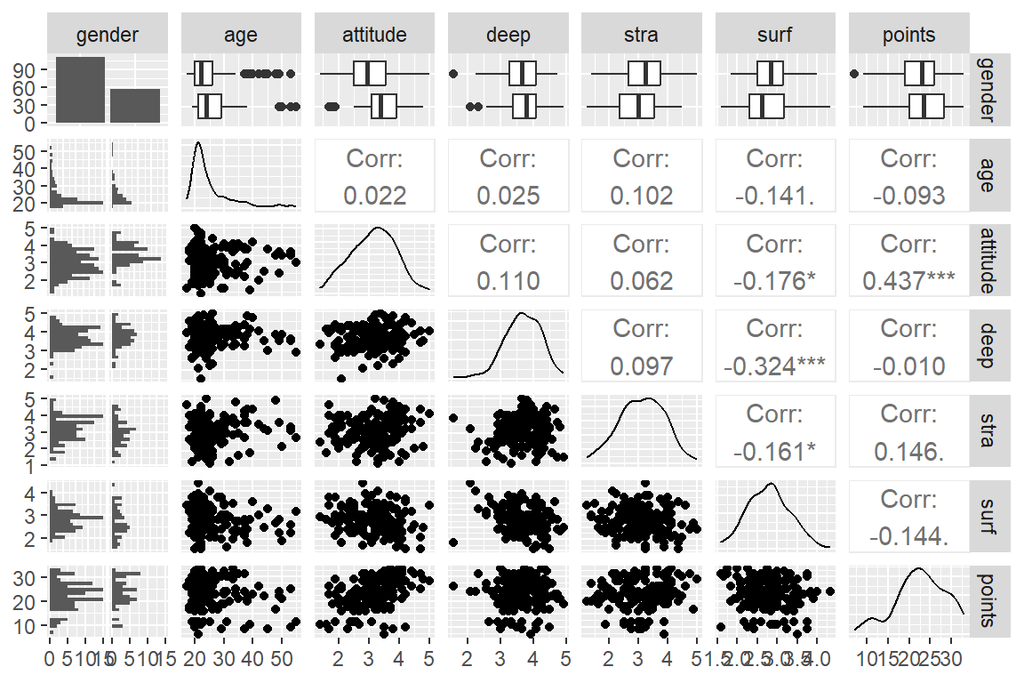

```r
ggpairs(lrn14, mapping = aes(), lower = list(combo = wrap("facethist", bins = 20)))
```

Next we explore the data using a scatter plot matrix. From the figure we can see the following:

- The variables seem to be mostly normally distributed. Age is skewed right and points are skewed left
- There are more women than men in the dataset
- Males seem to have on average better attitude
- There is a significant positive correlation between attitude and points
- There is a milder negative correlation between surface and deep learning (which is to be expected)